# Predictive models with best performing predictors using cumulative weekly data

Loading the required data…

```r
session.data <- readRDS("Intermediate_results/filtered_sessions_w2to13.RData")
res.use.ind <- read.csv("Intermediate_results/regularity_of_study/res_use_above_median_indicators_w2-13.csv")
exam.scores <- read.csv(file = "Intermediate_results/exam_scores_with_student_ids.csv")
# remove email data
exam.scores <- exam.scores %>% select(-2)
```

### Model BestRM: the best regular regression model with data for weeks 2-X (X=3:13)

The models should include the following predictors that were all significant in the best regression model with the whole course data:

- MCQ_ind
- EXE_ind
- Mon_count
- Tue_count
- Thu_count
- weekday_entropy
- weekly_entropy

#### Model BestRM_weeks_2-3

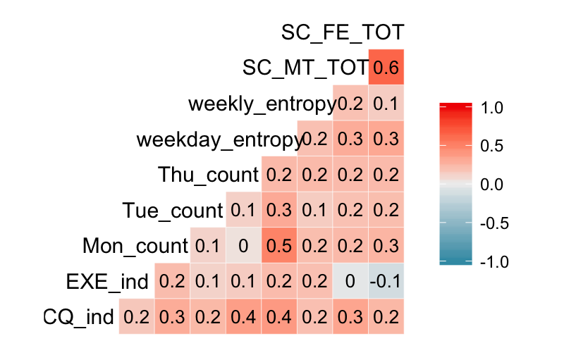

```r
lm_w23_data <- create.dataset(session.data, res.use.ind, c("MCQ", "EXE"), start_week = 2, end_week = 3)
plot.correlations(lm_w23_data %>% select(-user_id))
```

##### Regression model with final exam score as the outcome variable

```r
lm_w23_fe <- lm(SC_FE_TOT ~ ., data = lm_w23_data %>% select(-c(user_id, SC_MT_TOT)))
summary(lm_w23_fe)
```

```
Call:
lm(formula = SC_FE_TOT ~ ., data = lm_w23_data %>% select(-c(user_id,
    SC_MT_TOT)))

Residuals:
    Min      1Q  Median      3Q     Max
-26.498  -6.368  -0.148   6.168  22.719

Coefficients:
                Estimate Std. Error t value Pr(>|t|)
(Intercept)       29.880      3.955    7.55  2.2e-13 ***
MCQ_ind            0.798      0.570    1.40  0.16221
EXE_ind           -3.522      0.559   -6.31  6.6e-10 ***
Mon_count          0.629      0.167    3.76  0.00019 ***
Tue_count          0.420      0.138    3.04  0.00246 **
Thu_count          0.356      0.140    2.54  0.01148 *
weekday_entropy   20.231      5.328    3.80  0.00017 ***
weekly_entropy    15.144      8.736    1.73  0.08367 .
---
Signif. codes:  0 '***' 0.001 '**' 0.01 '*' 0.05 '.' 0.1 ' ' 1

Residual standard error: 8.69 on 469 degrees of freedom
Multiple R-squared:  0.224, Adjusted R-squared:  0.213
F-statistic: 19.4 on 7 and 469 DF,  p-value: <2e-16
```

Significant predictors: EXE_ind, Mon_count, Tue_count, Thu_count, weekday_entropy Not significant: MCQ_ind, weekly_entropy

R-squared: 0.2245 (adjusted R-squared: 0.2129).

```r
lm_w23_cv_R2 <- compute.CV.R2(lm_w23_data[,-c(1,9,10)], lm_w23_data$SC_FE_TOT, lm_w23_fe)
lm_w23_cv_R2[2]
```

```
cv_R2
0.192
```

Cross-validated R-squared: 0.192

For the sake of comparison, values for R-squared and adj. R-squared for the model with the same predictors and all the course weeks are 0.349 and 0.338, respectively.

Cross-validated standard error of prediction:

8.848 Max final exam score: 40; so, the error is 22.119 percent.

##### Regression model with midterm exam score as the outcome variable

```r
lm_w23_mt <- lm(SC_MT_TOT ~ ., data = lm_w23_data %>% select(-c(user_id, SC_FE_TOT)))
summary(lm_w23_mt)
```

```
Call:
lm(formula = SC_MT_TOT ~ ., data = lm_w23_data %>% select(-c(user_id,
    SC_FE_TOT)))

Residuals:
    Min      1Q  Median      3Q     Max
-13.680  -2.290   0.322   2.638   8.718

Coefficients:
                Estimate Std. Error t value Pr(>|t|)
(Intercept)      18.9394     1.6563   11.43  < 2e-16 ***
MCQ_ind           0.8817     0.2388    3.69  0.00025 ***
EXE_ind          -0.8330     0.2339   -3.56  0.00041 ***
Mon_count         0.1635     0.0701    2.33  0.02003 *
Tue_count         0.1447     0.0577    2.51  0.01256 *
Thu_count         0.1042     0.0587    1.78  0.07647 .
weekday_entropy   5.4762     2.2312    2.45  0.01447 *
weekly_entropy   13.5785     3.6585    3.71  0.00023 ***
---
Signif. codes:  0 '***' 0.001 '**' 0.01 '*' 0.05 '.' 0.1 ' ' 1

Residual standard error: 3.64 on 469 degrees of freedom
Multiple R-squared:  0.222, Adjusted R-squared:  0.21
F-statistic: 19.1 on 7 and 469 DF,  p-value: <2e-16
```

Significant predictors: MCQ_ind, EXE_ind, Mon_count, Tue_count, weekly_entropy, weekday_entropy Not significant: Thu_count

R-squared: 0.2216 (adjusted R-squared: 0.21).

```r
lm_w23_mt_cv_R2 <- compute.CV.R2(lm_w23_data[,-c(1,9,10)], lm_w23_data$SC_MT_TOT, lm_w23_mt)
#lm_w23_mt_cv_R2[2]
```

Cross-validated R-squared: 0.196

For the sake of comparison, values for R-squared and adj. R-squared for the model with the same predictors and course weeks before the midterm (weeks 2-5) are 0.2775 and 0.2667, respectively.

Cross-validated standard error of prediction:

3.692 Max midterm exam score: 20; so the error is 18.462 percent.

#### Model BestRM_weeks_2-4

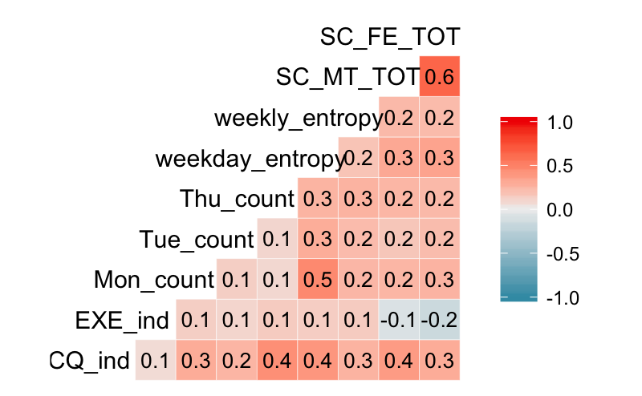

```r
lm_w24_data <- create.dataset(session.data, res.use.ind, c("MCQ", "EXE"), start_week = 2, end_week = 4)
plot.correlations(lm_w24_data %>% select(-user_id))
```

##### Regression model with final exam score as the outcome variable

```r
lm_w24_fe <- lm(SC_FE_TOT ~ ., data = lm_w24_data %>% select(-c(user_id, SC_MT_TOT)))
summary(lm_w24_fe)
```

```
Call:
lm(formula = SC_FE_TOT ~ ., data = lm_w24_data %>% select(-c(user_id,
    SC_MT_TOT)))

Residuals:
    Min      1Q  Median      3Q     Max
-25.684  -6.206  -0.025   6.024  21.994

Coefficients:
                Estimate Std. Error t value Pr(>|t|)
(Intercept)      31.2828     3.3011    9.48  < 2e-16 ***
MCQ_ind           0.8315     0.4070    2.04   0.0416 *
EXE_ind          -2.6297     0.4067   -6.47  2.5e-10 ***
Mon_count         0.3672     0.1118    3.28   0.0011 **
Tue_count         0.2326     0.0981    2.37   0.0181 *
Thu_count         0.2037     0.0990    2.06   0.0401 *
weekday_entropy  23.0787     5.6047    4.12  4.5e-05 ***
weekly_entropy   21.7801     8.7275    2.50   0.0129 *
---
Signif. codes:  0 '***' 0.001 '**' 0.01 '*' 0.05 '.' 0.1 ' ' 1

Residual standard error: 8.57 on 469 degrees of freedom
Multiple R-squared:  0.246, Adjusted R-squared:  0.235
F-statistic: 21.9 on 7 and 469 DF,  p-value: <2e-16
```

Having added the data for week 4, all predictors become significant.

Only slight improvement in the predicitve power (R-square: 0.246) over the model with data from weeks 2-3 (R-square: 0.224).

```r
lm_w24_cv_R2 <- compute.CV.R2(lm_w24_data[,-c(1,9,10)], lm_w24_data$SC_FE_TOT, lm_w24_fe)
#lm_w24_cv_R2[2]
```

Cross-validated R-squared: 0.212

Cross-validated standard error of prediction:

8.713 Max final exam score: 40; so the error is 21.782 percent.

##### Regression model with midterm exam score as the outcome variable

```r
lm_w24_mt <- lm(SC_MT_TOT ~ ., data = lm_w24_data %>% select(-c(user_id, SC_FE_TOT)))
summary(lm_w24_mt)
```

```
Call:
lm(formula = SC_MT_TOT ~ ., data = lm_w24_data %>% select(-c(user_id,
    SC_FE_TOT)))

Residuals:
    Min      1Q  Median      3Q     Max
-14.648  -2.328   0.447   2.555   8.097

Coefficients:
                Estimate Std. Error t value Pr(>|t|)
(Intercept)      19.4960     1.3704   14.23  < 2e-16 ***
MCQ_ind           0.7122     0.1690    4.22  3.0e-05 ***
EXE_ind          -0.6577     0.1688   -3.90  0.00011 ***
Mon_count         0.0891     0.0464    1.92  0.05564 .
Tue_count         0.0523     0.0407    1.29  0.19938
Thu_count         0.0445     0.0411    1.08  0.27929
weekday_entropy   6.4687     2.3267    2.78  0.00565 **
weekly_entropy   18.3097     3.6230    5.05  6.2e-07 ***
---
Signif. codes:  0 '***' 0.001 '**' 0.01 '*' 0.05 '.' 0.1 ' ' 1

Residual standard error: 3.56 on 469 degrees of freedom
Multiple R-squared:  0.257, Adjusted R-squared:  0.246
F-statistic: 23.1 on 7 and 469 DF,  p-value: <2e-16
```

Significant predictors: MCQ_ind, EXE_ind, weekly_entropy, weekday_entropy Not significant: Mon_count, Tue_count, Thu_count

Only slight improvement in the predicitve power (R-square: 0.257) over the model with data from weeks 2-3 (R-square: 0.222).

```r
lm_w24_mt_cv_R2 <- compute.CV.R2(lm_w24_data[,-c(1,9,10)], lm_w23_data$SC_MT_TOT, lm_w24_mt)
#lm_w24_mt_cv_R2[2]
```

Cross-validated R-squared: 0.234

For the sake of comparison, values for R-squared and adj. R-squared for the model with the same predictors and course weeks before the midterm (weeks 2-5) are 0.2775 and 0.2667, respectively.

Cross-validated standard error of prediction:

3.594 Max midterm exam score: 20; so the error is 17.97 percent.

Checking if the model satisfies the assumptions for linear regression:

[figure not shown]

```r
# assumption 1: the mean of residuals is zero
mean(lm_w24_mt$residuals)
# OK
# assumption 2: homoscedasticity of residuals or equal variance
# assumption 3: Normality of residuals
par(mfrow=c(2, 2))
plot(lm_w24_mt)
par(mfrow=c(1,1)) # Change back to 1 x 1
```

```r
# there are few outliers, in particular: 326, 69, 50; and a few potentially influential points
# assumption 4: no influential points
inf.indices <- head(sort(cooks.distance(lm_w24_mt), decreasing = T))
inf.indices
lm_w24_data[as.numeric(names(inf.indices)),]
```

|  | user_id | MCQ_ind | EXE_ind | Mon_count | Tue_count | Thu_count | weekday_entropy | weekly_entropy | SC_MT_TOT | SC_FE_TOT |
| --- | --- | --- | --- | --- | --- | --- | --- | --- | --- | --- |
| 259 | 984 | 0 | 1 | 0 | 1 | 0 | -0.244 | -0.693 | 0 | 0 |
| 95 | 795 | 3 | 3 | 18 | 9 | 12 | -0.182 | -0.294 | 6 | 20 |
| 50 | 745 | 2 | 0 | 1 | 4 | 11 | -0.247 | -0.298 | 0 | 0 |
| 69 | 765 | 2 | 1 | 4 | 1 | 1 | -0.184 | -0.304 | 0 | 14 |
| 264 | 990 | 3 | 3 | 2 | 14 | 1 | -0.206 | -0.295 | 6 | 15 |
| 377 | 1111 | 0 | 0 | 0 | 3 | 0 | -0.693 | -0.436 | 12 | 26 |

```r
# probable influential points: 259, 95, 50, 69
## assumption 5: predictors and residuals are uncorrelated
for(c in 2:8)
  print(cor.test(lm_w24_data[,c], lm_w24_mt$residuals))
# OK
## assumption 6: no multicolinearity between explanatory variables
vif(lm_w24_mt)
# OK, values below or equal to 2
```

The homoscedasticity of residuals is questionable; this seems to be due to a couple of influential point; should be consider for removal

#### Model BestRM_weeks_2-5

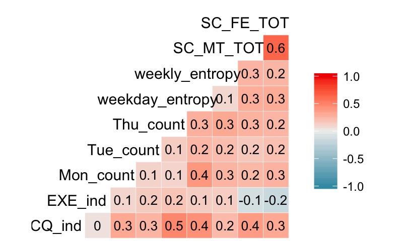

```r
lm_w25_data <- create.dataset(session.data, res.use.ind, c("MCQ", "EXE"), start_week = 2, end_week = 5)
#summary(lm_w25_data)
plot.correlations(lm_w25_data %>% select(-user_id))
```

##### Regression model with final exam score as the outcome variable

```r
lm_w25_fe <- lm(SC_FE_TOT ~ ., data = lm_w25_data %>% select(-c(user_id, SC_MT_TOT)))
summary(lm_w25_fe)
```

```
Call:
lm(formula = SC_FE_TOT ~ ., data = lm_w25_data %>% select(-c(user_id,
    SC_MT_TOT)))

Residuals:
    Min      1Q  Median      3Q     Max
-28.121  -6.259  -0.166   6.243  21.415

Coefficients:
                Estimate Std. Error t value Pr(>|t|)
(Intercept)      31.2255     2.8382   11.00  < 2e-16 ***
MCQ_ind           0.7242     0.3358    2.16   0.0315 *
EXE_ind          -2.2696     0.3374   -6.73  5.0e-11 ***
Mon_count         0.2577     0.0863    2.99   0.0030 **
Tue_count         0.1627     0.0769    2.12   0.0349 *
Thu_count         0.1832     0.0785    2.33   0.0201 *
weekday_entropy  23.8808     5.9240    4.03  6.5e-05 ***
weekly_entropy   26.4801     8.3793    3.16   0.0017 **
---
Signif. codes:  0 '***' 0.001 '**' 0.01 '*' 0.05 '.' 0.1 ' ' 1

Residual standard error: 8.52 on 469 degrees of freedom
Multiple R-squared:  0.254, Adjusted R-squared:  0.243
F-statistic: 22.8 on 7 and 469 DF,  p-value: <2e-16
```

All predictors are significant.

Slight improvement in the predicitve power (R-square: 0.254) over the model with data from weeks 2-4 (R-square: 0.246).

```r
lm_w25_cv_R2 <- compute.CV.R2(lm_w25_data[,-c(1,9,10)], lm_w25_data$SC_FE_TOT, lm_w25_fe)
#lm_w25_cv_R2[2]
```

Cross-validated R-squared: 0.227

Cross-validated standard error of prediction:

8.654 Max final exam score: 40; so the error is 21.634 percent.

Checking if the model satisfies the assumptions for linear regression:

[figure not shown]

```r
# assumption 1: the mean of residuals is zero
mean(lm_w25_fe$residuals)
# OK
# assumption 2: homoscedasticity of residuals or equal variance
# assumption 3: Normality of residuals
par(mfrow=c(2, 2))
plot(lm_w25_fe)
par(mfrow=c(1,1)) # Change back to 1 x 1
```

```r
# there are few outliers: 86, 50, 459; and a few potentially influential points
# assumption 4: no influential points
inf.indices <- head(sort(cooks.distance(lm_w25_fe), decreasing = T))
inf.indices
# lm_w25_data[as.numeric(names(inf.indices)),]
# the only real candidate for an influential point is 459
## assumption 5: predictors and residuals are uncorrelated
for(c in 2:8)
  print(cor.test(lm_w25_data[,c], lm_w25_fe$residuals))
# OK
## assumption 6: no multicolinearity between explanatory variables
vif(lm_w25_fe)
# OK, values below or equal to 2
```

All assumptions are satisified, though there is one potentially influential point

##### Regression model with midterm exam score as the outcome variable

```r
lm_w25_mt <- lm(SC_MT_TOT ~ ., data = lm_w25_data %>% select(-c(user_id, SC_FE_TOT)))
summary(lm_w25_mt)
```

```
Call:
lm(formula = SC_MT_TOT ~ ., data = lm_w25_data %>% select(-c(user_id,
    SC_FE_TOT)))

Residuals:
   Min     1Q Median     3Q    Max
-14.19  -2.33   0.28   2.49   7.53

Coefficients:
                Estimate Std. Error t value Pr(>|t|)
(Intercept)      18.8120     1.1674   16.11  < 2e-16 ***
MCQ_ind           0.5595     0.1381    4.05  6.0e-05 ***
EXE_ind          -0.5995     0.1388   -4.32  1.9e-05 ***
Mon_count         0.0612     0.0355    1.72   0.0852 .
Tue_count         0.0425     0.0316    1.34   0.1794
Thu_count         0.0494     0.0323    1.53   0.1265
weekday_entropy   7.1360     2.4367    2.93   0.0036 **
weekly_entropy   19.8505     3.4466    5.76  1.5e-08 ***
---
Signif. codes:  0 '***' 0.001 '**' 0.01 '*' 0.05 '.' 0.1 ' ' 1

Residual standard error: 3.51 on 469 degrees of freedom
Multiple R-squared:  0.278, Adjusted R-squared:  0.267
F-statistic: 25.7 on 7 and 469 DF,  p-value: <2e-16
```

The model predicting midterm exam score has only slightly higher predictive power (0.278) than the one predicting final exam score (0.254)

```r
lm_w25_mt_cv_R2 <- compute.CV.R2(lm_w25_data[,-c(1,9,10)], lm_w25_data$SC_MT_TOT, lm_w25_mt)
lm_w25_mt_cv_R2[2]
```

```
cv_R2
0.255
```

Cross-validated R-squared: 0.255

#### Model BestRM_weeks_2-7

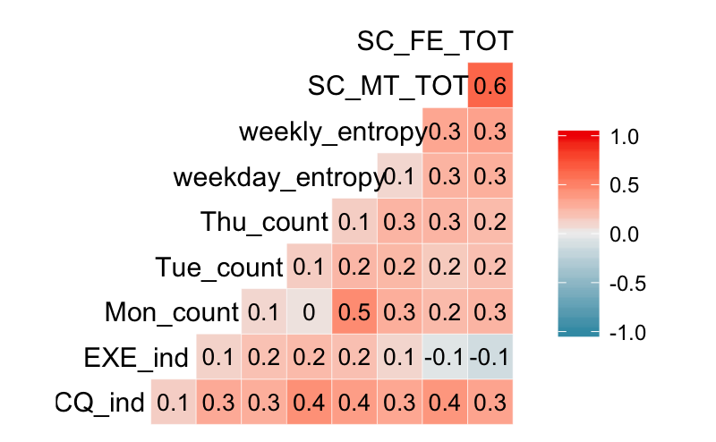

```r
lm_w27_data <- create.dataset(session.data, res.use.ind, c("MCQ", "EXE"), start_week = 2, end_week = 7)
plot.correlations(lm_w27_data %>% select(-user_id))
```

```r
lm_w27 <- lm(SC_FE_TOT ~ ., data = lm_w27_data %>% select(-c(user_id, SC_MT_TOT)))
summary(lm_w27)
```

```
Call:
lm(formula = SC_FE_TOT ~ ., data = lm_w27_data %>% select(-c(user_id,
    SC_MT_TOT)))

Residuals:
   Min     1Q Median     3Q    Max
-27.31  -6.25  -0.33   6.47  21.18

Coefficients:
                Estimate Std. Error t value Pr(>|t|)
(Intercept)      29.8817     2.7022   11.06  < 2e-16 ***
MCQ_ind           0.7836     0.2530    3.10  0.00207 **
EXE_ind          -1.5991     0.2545   -6.28  7.6e-10 ***
Mon_count         0.1756     0.0648    2.71  0.00697 **
Tue_count         0.1023     0.0549    1.86  0.06328 .
Thu_count         0.1422     0.0567    2.51  0.01244 *
weekday_entropy  26.3085     6.9634    3.78  0.00018 ***
weekly_entropy   32.1334     9.4222    3.41  0.00070 ***
---
Signif. codes:  0 '***' 0.001 '**' 0.01 '*' 0.05 '.' 0.1 ' ' 1

Residual standard error: 8.49 on 469 degrees of freedom
Multiple R-squared:  0.259, Adjusted R-squared:  0.248
F-statistic: 23.4 on 7 and 469 DF,  p-value: <2e-16
```

Significant predictors: MCQ_ind, EXE_ind, Mon_count, Thu_count, weekly_entropy, weekday_entropy Not significant: Tue_count

Slight improvement in the predicitve power (R-square: 0.259) over the model with data from weeks 2-5 (R-square: 0.254).

```r
lm_w27_cv_R2 <- compute.CV.R2(lm_w27_data[,-c(1,9,10)], lm_w27_data$SC_FE_TOT, lm_w27)
```

Cross-validated R-squared: 0.223

Cross-validated standard error of prediction:

8.639 Max final exam score: 40; so the error is 21.597 percent.

#### Model BestRM_weeks_2-8

```r
lm_w28_data <- create.dataset(session.data, res.use.ind, c("MCQ", "EXE"), start_week = 2, end_week = 8)
```

```r
lm_w28 <- lm(SC_FE_TOT ~ ., data = lm_w28_data %>% select(-c(user_id, SC_MT_TOT)))
summary(lm_w28)
```

```
Call:
lm(formula = SC_FE_TOT ~ ., data = lm_w28_data %>% select(-c(user_id,
    SC_MT_TOT)))

Residuals:
    Min      1Q  Median      3Q     Max
-27.949  -6.147  -0.152   6.102  21.746

Coefficients:
                Estimate Std. Error t value Pr(>|t|)
(Intercept)      29.4264     2.5636   11.48  < 2e-16 ***
MCQ_ind           0.7822     0.2242    3.49  0.00053 ***
EXE_ind          -1.4568     0.2198   -6.63  9.4e-11 ***
Mon_count         0.1710     0.0558    3.06  0.00231 **
Tue_count         0.0784     0.0470    1.67  0.09594 .
Thu_count         0.1223     0.0506    2.42  0.01604 *
weekday_entropy  26.3602     6.8810    3.83  0.00015 ***
weekly_entropy   32.3424     9.1197    3.55  0.00043 ***
---
Signif. codes:  0 '***' 0.001 '**' 0.01 '*' 0.05 '.' 0.1 ' ' 1

Residual standard error: 8.34 on 469 degrees of freedom
Multiple R-squared:  0.286, Adjusted R-squared:  0.275
F-statistic: 26.8 on 7 and 469 DF,  p-value: <2e-16
```

Significant predictors: MCQ_ind, EXE_ind, Mon_count, Thu_count, weekly_entropy, weekday_entropy Not significant: Tue_count

Only very slight improvement in the predicitve power (R-square: 0.286) over the model with data from weeks 2-7 (R-square: 0.259).

```r
lm_w28_cv_R2 <- compute.CV.R2(lm_w28_data[,-c(1,9,10)], lm_w28_data$SC_FE_TOT, lm_w28)
```

Cross-validated R-squared: 0.249

Cross-validated standard error of prediction:

8.485 Max final exam score: 40; so the error is 21.212 percent.

#### Model BestRM_weeks_2-9

```r
lm_w29_data <- create.dataset(session.data, res.use.ind, c("MCQ", "EXE"), start_week = 2, end_week = 9)
```

```r
lm_w29 <- lm(SC_FE_TOT ~ ., data = lm_w29_data %>% select(-c(user_id, SC_MT_TOT)))
summary(lm_w29)
```

```
Call:
lm(formula = SC_FE_TOT ~ ., data = lm_w29_data %>% select(-c(user_id,
    SC_MT_TOT)))

Residuals:
    Min      1Q  Median      3Q     Max
-26.544  -5.704  -0.295   6.150  21.398

Coefficients:
                Estimate Std. Error t value Pr(>|t|)
(Intercept)      28.2425     2.4639   11.46  < 2e-16 ***
MCQ_ind           0.8484     0.1995    4.25  2.5e-05 ***
EXE_ind          -1.3319     0.2013   -6.62  1.0e-10 ***
Mon_count         0.1433     0.0535    2.68   0.0076 **
Tue_count         0.0803     0.0422    1.91   0.0573 .
Thu_count         0.1108     0.0470    2.36   0.0189 *
weekday_entropy  22.3384     6.7946    3.29   0.0011 **
weekly_entropy   34.8484     8.8542    3.94  9.5e-05 ***
---
Signif. codes:  0 '***' 0.001 '**' 0.01 '*' 0.05 '.' 0.1 ' ' 1

Residual standard error: 8.23 on 469 degrees of freedom
Multiple R-squared:  0.305, Adjusted R-squared:  0.294
F-statistic: 29.4 on 7 and 469 DF,  p-value: <2e-16
```

Significant predictors: MCQ_ind, EXE_ind, Mon_count, Thu_count, weekly_entropy, weekday_entropy Not significant: Tue_count

Only very slight improvement in the predicitve power (R-square: 0.305) over the model with data from weeks 2-8 (R-square: 0.286).

```r
lm_w29_cv_R2 <- compute.CV.R2(lm_w29_data[,-c(1,9,10)], lm_w29_data$SC_FE_TOT, lm_w29)
```

Cross-validated R-squared: 0.268

Cross-validated standard error of prediction:

8.36 Max final exam score: 40; so the error is 20.901 percent.

#### Model BestRM_weeks_2-10

```r
lm_w210_data <- create.dataset(session.data, res.use.ind, c("MCQ", "EXE"), start_week = 2, end_week = 10)
```

```r
lm_w210 <- lm(SC_FE_TOT ~ ., data = lm_w210_data %>% select(-c(user_id, SC_MT_TOT)))
summary(lm_w210)
```

```
Call:
lm(formula = SC_FE_TOT ~ ., data = lm_w210_data %>% select(-c(user_id,
    SC_MT_TOT)))

Residuals:
    Min      1Q  Median      3Q     Max
-26.592  -5.785  -0.343   5.935  22.025

Coefficients:
                Estimate Std. Error t value Pr(>|t|)
(Intercept)      26.8080     2.4027   11.16  < 2e-16 ***
MCQ_ind           0.8528     0.1820    4.69  3.7e-06 ***
EXE_ind          -1.1863     0.1806   -6.57  1.3e-10 ***
Mon_count         0.1271     0.0466    2.72  0.00668 **
Tue_count         0.0751     0.0387    1.94  0.05290 .
Thu_count         0.0997     0.0430    2.32  0.02091 *
weekday_entropy  21.1798     6.9153    3.06  0.00232 **
weekly_entropy   32.4890     8.7514    3.71  0.00023 ***
---
Signif. codes:  0 '***' 0.001 '**' 0.01 '*' 0.05 '.' 0.1 ' ' 1

Residual standard error: 8.15 on 469 degrees of freedom
Multiple R-squared:  0.318, Adjusted R-squared:  0.308
F-statistic: 31.2 on 7 and 469 DF,  p-value: <2e-16
```

Significant predictors: MCQ_ind, EXE_ind, Mon_count, Thu_count, weekly_entropy, weekday_entropy Not significant: Tue_count

Only very slight improvement in the predicitve power (R-square: 0.318) over the model with data from weeks 2-9 (R-square: 0.305).

```r
lm_w210_cv_R2 <- compute.CV.R2(lm_w210_data[,-c(1,9,10)], lm_w210_data$SC_FE_TOT, lm_w210)
```

Cross-validated R-squared: 0.284

Cross-validated standard error of prediction:

8.276 Max final exam score: 40; so the error is 20.69 percent.

#### Model BestRM_weeks_2-11

```r
lm_w211_data <- create.dataset(session.data, res.use.ind, c("MCQ", "EXE"), start_week = 2, end_week = 11)
```

```r
lm_w211 <- lm(SC_FE_TOT ~ ., data = lm_w211_data %>% select(-c(user_id, SC_MT_TOT)))
summary(lm_w211)
```

```
Call:
lm(formula = SC_FE_TOT ~ ., data = lm_w211_data %>% select(-c(user_id,
    SC_MT_TOT)))

Residuals:
    Min      1Q  Median      3Q     Max
-25.425  -5.597  -0.382   5.679  21.144

Coefficients:
                Estimate Std. Error t value Pr(>|t|)
(Intercept)      26.7201     2.3521   11.36  < 2e-16 ***
MCQ_ind           0.8309     0.1663    5.00  8.3e-07 ***
EXE_ind          -1.1415     0.1613   -7.08  5.4e-12 ***
Mon_count         0.1028     0.0418    2.46  0.01434 *
Tue_count         0.0715     0.0355    2.01  0.04469 *
Thu_count         0.0906     0.0398    2.28  0.02321 *
weekday_entropy  20.4384     6.7408    3.03  0.00256 **
weekly_entropy   33.1151     8.7655    3.78  0.00018 ***
---
Signif. codes:  0 '***' 0.001 '**' 0.01 '*' 0.05 '.' 0.1 ' ' 1

Residual standard error: 8.04 on 469 degrees of freedom
Multiple R-squared:  0.336, Adjusted R-squared:  0.326
F-statistic: 33.9 on 7 and 469 DF,  p-value: <2e-16
```

All predictors are significant.

Slight improvement in the predicitve power (R-square: 0.336) over the model with data from weeks 2-10 (R-square: 0.318).

```r
lm_w211_cv_R2 <- compute.CV.R2(lm_w211_data[,-c(1,9,10)], lm_w211_data$SC_FE_TOT, lm_w211)
```

Cross-validated R-squared: 0.302

Cross-validated standard error of prediction:

8.166 Max final exam score: 40; so the error is 20.415 percent.

### Trace the change of R2 of the FE predictive model as the weekly data accumulate

```r
# create a data frame with R-square, adj R-square, and cross-validated R2 values for all the models
# final exam
r2.fe.df <- data.frame(week=c(3:5,7:12),
                    R2=c(getR2(lm_w23_fe), getR2(lm_w24_fe), getR2(lm_w25_fe), getR2(lm_w27),
                         getR2(lm_w28), getR2(lm_w29), getR2(lm_w210), getR2(lm_w211), 0.3492),
                    Adj_R2=c(getAdjR2(lm_w23_fe), getAdjR2(lm_w24_fe), getAdjR2(lm_w25_fe),
                             getAdjR2(lm_w27), getAdjR2(lm_w28), getAdjR2(lm_w29),
                             getAdjR2(lm_w210),getAdjR2(lm_w211), 0.3381),
                    CV_R2=c(lm_w23_cv_R2[2], lm_w24_cv_R2[2], lm_w25_cv_R2[2], lm_w27_cv_R2[2],
                            lm_w28_cv_R2[2], lm_w29_cv_R2[2], lm_w210_cv_R2[2],
                            lm_w211_cv_R2[2], 0.3243))
# midterm exam
r2.mt.df <- data.frame(week=c(3:5),
                    R2=c(getR2(lm_w23_mt), getR2(lm_w24_mt), getR2(lm_w25_mt)),
                    Adj_R2=c(getAdjR2(lm_w23_mt), getAdjR2(lm_w24_mt), getAdjR2(lm_w25_mt)),
                    CV_R2=c(lm_w23_mt_cv_R2[2], lm_w24_mt_cv_R2[2], lm_w25_mt_cv_R2[2]))
```

Plot the data

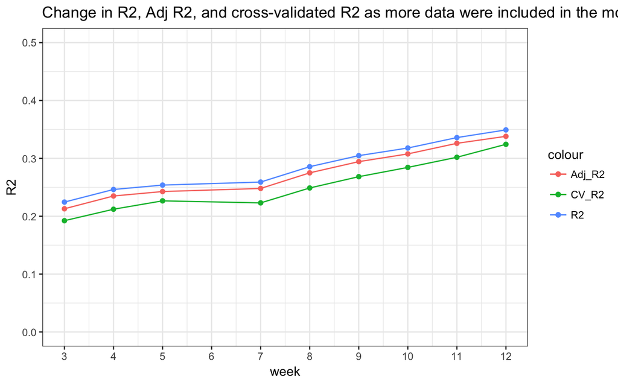

```r
plot.R2.change(r2.fe.df, end.week = 12)
```

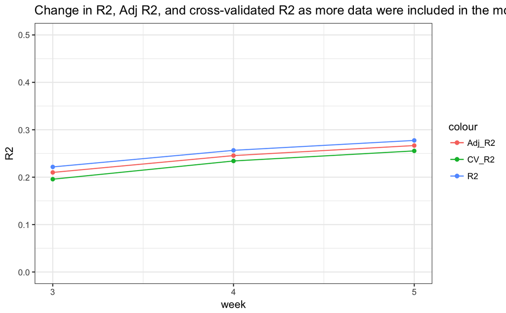

```r
plot.R2.change(r2.mt.df, end.week = 5)
```

### Trace the change cross-validated standard error of FE prediction

```r
# create a data frame with CV standard errors for all the models
cv.err.df <- data.frame(week=c(3:5,7:12),
                        CV_FE_err=c(lm_w23_cv_err, lm_w24_cv_err, lm_w25_cv_err, lm_w27_cv_err,
                                 lm_w28_cv_err, lm_w29_cv_err, lm_w210_cv_err, lm_w211_cv_err,
                                 8.08),
                        CV_MT_err=c(lm_w23_mt_cv_err, lm_w24_mt_cv_err, lm_w25_mt_cv_err,
                                    rep(NA, 6)))
cv.err.mt.df <- data.frame(week=c(3:5,7:12),
                        CV_err=c(lm_w23_cv_err, lm_w24_cv_err, lm_w25_cv_err, lm_w27_cv_err,
                                 lm_w28_cv_err, lm_w29_cv_err, lm_w210_cv_err, lm_w211_cv_err,
                                 8.08))
```

Plot the data

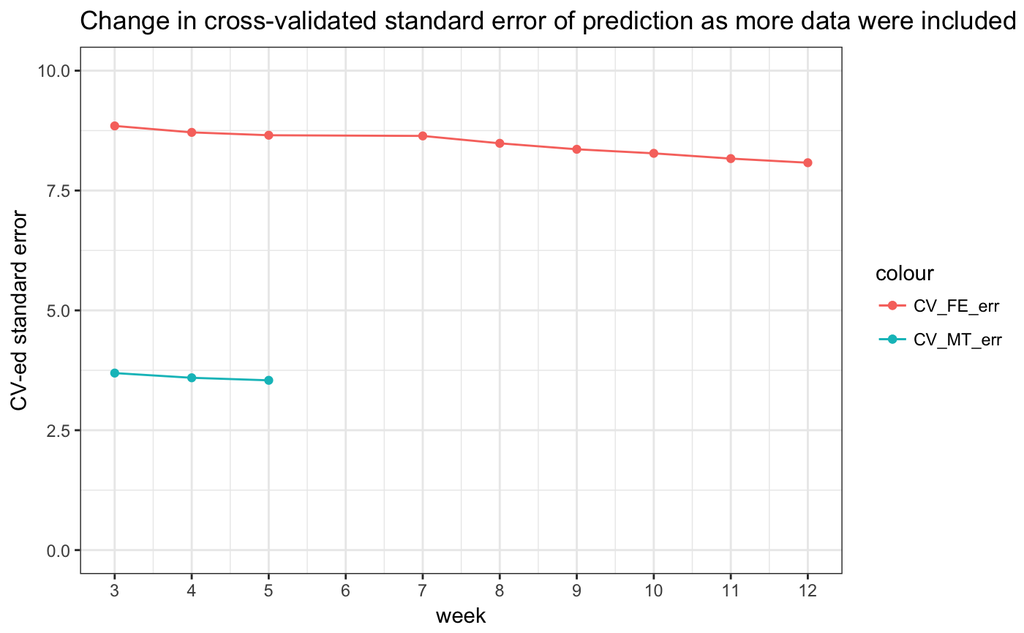

```r
ggplot(cv.err.df, aes(week)) +
  geom_line(aes(y = CV_FE_err, colour = "CV_FE_err")) +
  geom_point(aes(y = CV_FE_err, colour = "CV_FE_err")) +
  geom_line(aes(y = CV_MT_err, colour = "CV_MT_err")) +
  geom_point(aes(y = CV_MT_err, colour = "CV_MT_err")) +
  expand_limits(y=c(0,10)) +
  ylab("CV-ed standard error") +
  scale_x_continuous(breaks=seq(2,13,1)) +
  ggtitle("Change in cross-validated standard error of prediction as more data were included in the model") +
  theme_bw()
```